# pset4_steiner

erika steiner

2025-05-15

*1. Extract data from Tables 1 through 4 of the article, constructing a dataset or dataframe that can be analyzed with a statistical package.*

(Per Ed Discussion Board, extracting data from Tables 1 through 5).

VPR and VPER 2015 form coefficients

| Indicators | RR Coefficient | 95% CI | ChiSquared | Present | Absent | N/S | Percent Valid |
| --- | --- | --- | --- | --- | --- | --- | --- |
| **Table 1. Reported episode indicators associated with recidivism after 6 months included in the VPR-2015 form.** |  |  |  |  |  |  |  |
| I-1. Presence of any type of violence carried out by the aggressor | 1.10 | [0.89-1.37] | 0.810 | 5139 | 1404 | 70 | 98.9 |
| I-2. Psychological Violence | 1.19 | [0.98-1.48] | 3.370 | 4115 | 2204 | 294 | 95.6 |
| I-3. Physical violence | 0.99 | [0.82-1.19] | 0.000 | 4369 | 2150 | 94 | 98.6 |
| I-4. Sexual violence | 1.14 | [0.80-1.62] | 0.520 | 360 | 5942 | 311 | 95.3 |
| I-5. Victim’s defensive reaction to physical aggression | 1.11 | [0.92-1.35] | 1.234 | 1718 | 4305 | 590 | 91.1 |
| I-6. Use of weapons/objects against partner | 1.46 | [1.15-1.86]** | 9.510 | 673 | 5813 | 127 | 98.1 |
| I-7. The aggressor has access to firearms | 1.13 | [0.78-1.63] | 0.430 | 347 | 5484 | 782 | 88.2 |
| I-8. The aggressor is an expert in combat techniques | 1.37 | [0.85-2.21] | 1.710 | 164 | 5351 | 1098 | 83.4 |
| I-9. Presence of threats/plans aimed to cause the victim harm | 1.07 | [0.89-1.28] | 0.530 | 3954 | 2274 | 385 | 94.2 |
| I-10. An escalation in aggression or threats in the last 6 months | 1.32 | [1.11-1.58]** | 9.700 | 2640 | 3398 | 575 | 91.3 |
| **2. Indicators related to the aggressor associated with recidivism after 6 months included in the VPR-2015 form.** |  |  |  |  |  |  |  |
| I-11. They have shown exaggerated jealousy or have suspected their partner of infidelity in the last 6 months | 1.54 | [1.28-1.85]*** | 21.940 | 2748 | 3255 | 610 | 90.8 |
| I-12. They have shown controlling behaviors in the last 6 months | 1.80 | [1.49-2.18]*** | 38.360 | 2979 | 2991 | 643 | 90.3 |
| I-13. In the last 6 months they have shown harassing behaviors | 1.38 | [1.15-1.66]*** | 11.900 | 2149 | 3765 | 699 | 89.4 |
| I-14.In the last year they have done material damage | 1.30 | [1.07-1.57]** | 7.540 | 1774 | 4290 | 549 | 91.7 |
| I-15. In the last year they have disrespected an authority figure | 1.58 | [1.22-2.04]*** | 12.000 | 572 | 5353 | 688 | 89.6 |
| I-16. In the last year they have committed an aggression against third parties and/or animals. | 1.31 | [1.01-1.71] | 4.180 | 687 | 5143 | 783 | 88.2 |
| I-17. In the last year they have made threats and slights towards third parties. | 1.26 | [1.03-1.56] | 5.050 | 1344 | 4385 | 884 | 86.6 |
| I-18. Presence of problems in their life in the last 6 months. | 1.45 | [1.18-1.72]*** | 13.170 | 1482 | 3648 | 1483 | 77.6 |
| I-19. Presence of a criminal record | 1.64 | [1.38-1.95]*** | 31.570 | 2581 | 3729 | 303 | 95.4 |
| I-20. Presence of past breakings of sentence conditions | 1.85 | [1.34-2.56]*** | 13.730 | 267 | 5901 | 445 | 93.3 |
| I-21. Presence of physical/sexual aggression records | 1.58 | [1.28-1.96]*** | 18.360 | 934 | 5239 | 440 | 93.3 |
| I-22. Presence of gender violence records against other partners | 1.44 | [1.15-1.80]*** | 10.290 | 861 | 5322 | 430 | 93.5 |
| I-23. Presence of mental/psychiatric disorder | 1.27 | [0.89-1.80] | 1.810 | 343 | 5328 | 942 | 85.8 |
| I-24. Presence of suicidal ideas or attempts | 1.67 | [1.32-2.13]*** | 17.550 | 625 | 5292 | 696 | 89.5 |
| I-25. Presence of any type of addiction or substance abuse (alcohol and drugs) | 1.39 | [1.15-1.67]*** | 12.180 | 2499 | 3231 | 883 | 86.6 |
| I-26. Presence of a gender or domestic violence history within their family | 1.63 | [1.23-2.16]*** | 11.620 | 547 | 3701 | 2365 | 64.2 |
| **3. Indicators of victim vulnerability associated with recidivism after 6 months included in the de VPR-2015 form.** |  |  |  |  |  |  |  |
| I-27. Presence of any type of disability | 1.30 | [0.77-2.20] | 0.970 | 136 | 6310 | 167 | 97.5 |
| I-28. Victim is in gestation period | 1.06 | [0.61-1.84] | 0.050 | 154 | 6255 | 204 | 96.9 |
| I-29. Victim suffers from a serious illness | 1.00 | [0.55-1.84] | 0.000 | 137 | 6185 | 291 | 95.6 |
| I-30. Victim is a foreigner | 0.73 | [0.58-0.92]** | 6.980 | 1698 | 4862 | 53 | 99.2 |
| I-31. Victim has no social/family support | 0.98 | [0.76-1.26] | 0.010 | 903 | 5104 | 606 | 90.8 |
| I-32. Victim has a mental/psychiatric disorder | 0.82 | [0.49-1.38] | 0.530 | 230 | 5963 | 420 | 93.6 |
| I-33. Victim has suicidal ideas/attempts | 1.34 | [0.87-2.05] | 1.810 | 206 | 6036 | 371 | 94.4 |
| I-34. Victim has any kind of addiction or engages in substance abuse (alcohol and drugs) | 1.23 | [0.82-1.84] | 1.020 | 260 | 5753 | 600 | 90.9 |
| I-35. There is a history of gender or domestic violence within their family | 1.40 | [0.91-2.15] | 2.390 | 205 | 5504 | 904 | 86.3 |
| I-36. Victim is economically dependent on the aggressor | 0.86 | [0.69-1.07] | 1.690 | 1446 | 4537 | 630 | 90.5 |
| I-37. Victim has minors or family members under their care | 1.05 | [0.89-1.25] | 0.400 | 3661 | 2952 | 0 | 100.0 |
| **4. Indicators of aggravating circumstances associated with recidivism after 6 months included in the VPR-2015 form.** |  |  |  |  |  |  |  |
| I-38. The victim has withdrawn complaints in the past | 1.13 | [0.78-1.62] | 0.430 | 352 | 5953 | 308 | 95.3 |
| I-39. The victim has suffered gender violence by the hands of other aggressors in the past | 1.39 | [1.07-1.81] | 6.290 | 619 | 5504 | 490 | 92.6 |
| I-40. The victim has expressed their desire to end the relationship to the aggressor at least 6 months ago | 1.48 | [1.22-1.79]*** | 16.420 | 3373 | 2610 | 630 | 90.5 |
| I-41. There have been reports of mutual violence | 1.01 | [0.77-1.32] | 0.010 | 834 | 5004 | 775 | 88.3 |
| I-42. The victim fears for the physical integrity of the minors or family members under their care | 1.20 | [0.97-1.42] | 2.980 | 1186 | 5427 | 0 | 100.0 |
| I-43. The victim thinks that the aggressor is capable of attacking them in a violent way or even of killing them | 1.33 | [1.10-1.61]** | 9.180 | 2020 | 3510 | 1083 | 83.6 |
| **5. Indicators associated with recidivism cases included in the VPER-2015 form.** |  |  |  |  |  |  |  |
| I-1. The aggressor has contacted the victim through technological means | 6.69 | [4.43-10.10]*** | 106.820 | 155 | 3499 | 319 | 92.0 |
| I-2. The aggressor has contacted the victim through third parties | 1.60 | [0.91-2.83] | 2.750 | 188 | 3463 | 322 | 91.9 |
| I-3. The aggressor has physically gotten closer to the victim | 11.99 | [8.47-16.96]*** | 295.670 | 208 | 3461 | 304 | 92.3 |
| I-4. The aggressor is an escaped convict or is in an unknown location | 1.82 | [1.06-3.11] | 4.980 | 153 | 3820 | 0 | 100.0 |
| I-5. The aggressor has distanced themselves from the victim | 0.06 | [0.05-0.08]*** | 551.820 | 3399 | 574 | 0 | 100.0 |
| I-6. The aggressor shows a peaceful attitude | 0.09 | [0.06-0.11]*** | 417.630 | 3368 | 605 | 0 | 100.0 |
| I-7. The aggressor exteriorizes a respectful attitude toward the law | 0.18 | [0.14-0.24]*** | 166.580 | 3523 | 450 | 0 | 100.0 |
| I-8. The aggressor shows regret | 0.28 | [0.20-0.41]*** | 52.280 | 1199 | 767 | 2007 | 49.5 |
| I-9. The aggressor joins Help programs | 0.33 | [0.19-0.57]*** | 17.200 | 500 | 1318 | 2155 | 45.8 |
| I-10. The aggressor follows the requirements of the charges and of the family separation | 0.26 | [0.17-0.39]*** | 48.000 | 2009 | 534 | 1430 | 64.0 |
| I-11. The victim has resumed living with the aggressor | 4.36 | [2.67-7.12]*** | 41.160 | 104 | 3869 | 0 | 100.0 |
| I-12. The victim doesn’t report any episodes to file a complaint about, and/or turns down the offer of protection | 2.85 | [2.09-3.88]*** | 48.180 | 447 | 3526 | 0 | 100.0 |
| I-13. The victim engages in activities that threaten their own security | 6.15 | [4.37-8.64]*** | 138.080 | 217 | 3756 | 0 | 100.0 |
| I-14. The victim is in a situation of economical dependency | 1.26 | [0.90-1.77] | 1.940 | 604 | 3369 | 0 | 100.0 |
| I-15. The victim has minors or family member under their care | 1.22 | [0.94-1.58] | 2.270 | 2125 | 1848 | 0 | 100.0 |
| I-16. Judicial proceedings to carry out a separation/divorce unwanted by the aggressor | 1.52 | [1.11-2.08]** | 6.950 | 635 | 3338 | 0 | 100.0 |
| I-17. The victim establishes a new sentimental relationship, which is not approved by the aggressor | 1.41 | [0.85-2.33] | 1.860 | 215 | 3758 | 0 | 100.0 |
| I-18. The aggressor establishes a new sentimental relationship | 1.41 | [0.90-2.21] | 2.290 | 268 | 2383 | 1322 | 66.7 |
| I-19. The aggressor has a stable economic and labor situation | 0.63 | [0.47-0.85]** | 9.150 | 1823 | 1327 | 0 | 79.3 |
| I-20. The aggressor has favorable family and social support | 0.58 | [0.42-0.82]** | 9.870 | 2070 | 690 | 1213 | 69.5 |
| I-21. Presence of a conflict about their responsibilities in the children’s care | 2.74 | [2.00-3.75]*** | 42.990 | 522 | 2980 | 471 | 88.1 |
| I-22. The victim feels that the risk level is nonexistent | 0.29 | [0.19-0.44]*** | 36.380 | 990 | 2512 | 471 | 88.1 |

Note:  
** p<0.01, *** p <0.001, CI of ChiSq is 95%, The N/S Category (missing data) groups the cases where this option was marked and the lost cases together.

*2. The authors use chi-square statistics to test for association between their candidate predictors and DV recidivism. On the basis of the authors’ analysis, how many significant predictors are there at the 5 percent level?*

Significant Chi-Squared Values

| Indicators | RR Coefficient | 95% CI | ChiSquared |
| --- | --- | --- | --- |
| I-1. Presence of any type of violence carried out by the aggressor | 1.10 | [0.89-1.37] | 0.81000 |
| I-2. Psychological Violence | 1.19 | [0.98-1.48] | 3.37000 |
| I-3. Physical violence | 0.99 | [0.82-1.19] | 0.00000 |
| I-4. Sexual violence | 1.14 | [0.80-1.62] | 0.52000 |
| I-5. Victim’s defensive reaction to physical aggression | 1.11 | [0.92-1.35] | 1.23400 |
| I-6. Use of weapons/objects against partner | 1.46 | [1.15-1.86]** | 9.51000 |
| I-7. The aggressor has access to firearms | 1.13 | [0.78-1.63] | 0.43000 |
| I-8. The aggressor is an expert in combat techniques | 1.37 | [0.85-2.21] | 1.71000 |
| I-9. Presence of threats/plans aimed to cause the victim harm | 1.07 | [0.89-1.28] | 0.53000 |
| I-10. An escalation in aggression or threats in the last 6 months | 1.32 | [1.11-1.58]** | 9.70000 |
| I-11. They have shown exaggerated jealousy or have suspected their partner of infidelity in the last 6 months | 1.54 | [1.28-1.85]*** | 21.94000 |
| I-12. They have shown controlling behaviors in the last 6 months | 1.80 | [1.49-2.18]*** | 38.36000 |
| I-13. In the last 6 months they have shown harassing behaviors | 1.38 | [1.15-1.66]*** | 11.90000 |
| I-14.In the last year they have done material damage | 1.30 | [1.07-1.57]** | 7.54000 |
| I-15. In the last year they have disrespected an authority figure | 1.58 | [1.22-2.04]*** | 12.00000 |
| I-16. In the last year they have committed an aggression against third parties and/or animals. | 1.31 | [1.01-1.71] | 4.18000 |
| I-17. In the last year they have made threats and slights towards third parties. | 1.26 | [1.03-1.56] | 5.05000 |
| I-18. Presence of problems in their life in the last 6 months. | 1.45 | [1.18-1.72]*** | 13.17000 |
| I-19. Presence of a criminal record | 1.64 | [1.38-1.95]*** | 31.57000 |
| I-20. Presence of past breakings of sentence conditions | 1.85 | [1.34-2.56]*** | 13.73000 |
| I-21. Presence of physical/sexual aggression records | 1.58 | [1.28-1.96]*** | 18.36000 |
| I-22. Presence of gender violence records against other partners | 1.44 | [1.15-1.80]*** | 10.29000 |
| I-23. Presence of mental/psychiatric disorder | 1.27 | [0.89-1.80] | 1.81000 |
| I-24. Presence of suicidal ideas or attempts | 1.67 | [1.32-2.13]*** | 17.55000 |
| I-25. Presence of any type of addiction or substance abuse (alcohol and drugs) | 1.39 | [1.15-1.67]*** | 12.18000 |
| I-26. Presence of a gender or domestic violence history within their family | 1.63 | [1.23-2.16]*** | 11.62000 |
| I-27. Presence of any type of disability | 1.30 | [0.77-2.20] | 0.97000 |
| I-28. Victim is in gestation period | 1.06 | [0.61-1.84] | 0.05000 |
| I-29. Victim suffers from a serious illness | 1.00 | [0.55-1.84] | 0.00000 |
| I-30. Victim is a foreigner | 0.73 | [0.58-0.92]** | 6.98000 |
| I-31. Victim has no social/family support | 0.98 | [0.76-1.26] | 0.01000 |
| I-32. Victim has a mental/psychiatric disorder | 0.82 | [0.49-1.38] | 0.53000 |
| I-33. Victim has suicidal ideas/attempts | 1.34 | [0.87-2.05] | 1.81000 |
| I-34. Victim has any kind of addiction or engages in substance abuse (alcohol and drugs) | 1.23 | [0.82-1.84] | 1.02000 |
| I-35. There is a history of gender or domestic violence within their family | 1.40 | [0.91-2.15] | 2.39000 |
| I-36. Victim is economically dependent on the aggressor | 0.86 | [0.69-1.07] | 1.69000 |
| I-37. Victim has minors or family members under their care | 1.05 | [0.89-1.25] | 0.40000 |
| I-38. The victim has withdrawn complaints in the past | 1.13 | [0.78-1.62] | 0.43000 |
| I-39. The victim has suffered gender violence by the hands of other aggressors in the past | 1.39 | [1.07-1.81] | 6.29000 |
| I-40. The victim has expressed their desire to end the relationship to the aggressor at least 6 months ago | 1.48 | [1.22-1.79]*** | 16.42000 |
| I-41. There have been reports of mutual violence | 1.01 | [0.77-1.32] | 0.01000 |
| I-42. The victim fears for the physical integrity of the minors or family members under their care | 1.20 | [0.97-1.42] | 2.98000 |
| I-43. The victim thinks that the aggressor is capable of attacking them in a violent way or even of killing them | 1.33 | [1.10-1.61]** | 9.18000 |
| I-1. The aggressor has contacted the victim through technological means | 6.69 | [4.43-10.10]*** | 106.82000 |
| I-2. The aggressor has contacted the victim through third parties | 1.60 | [0.91-2.83] | 2.75000 |
| I-3. The aggressor has physically gotten closer to the victim | 11.99 | [8.47-16.96]*** | 295.67000 |
| I-4. The aggressor is an escaped convict or is in an unknown location | 1.82 | [1.06-3.11] | 4.98000 |
| I-5. The aggressor has distanced themselves from the victim | 0.06 | [0.05-0.08]*** | 551.82000 |
| I-6. The aggressor shows a peaceful attitude | 0.09 | [0.06-0.11]*** | 417.63000 |
| I-7. The aggressor exteriorizes a respectful attitude toward the law | 0.18 | [0.14-0.24]*** | 166.58000 |
| I-8. The aggressor shows regret | 0.28 | [0.20-0.41]*** | 52.28000 |
| I-9. The aggressor joins Help programs | 0.33 | [0.19-0.57]*** | 17.20000 |
| I-10. The aggressor follows the requirements of the charges and of the family separation | 0.26 | [0.17-0.39]*** | 48.00000 |
| I-11. The victim has resumed living with the aggressor | 4.36 | [2.67-7.12]*** | 41.16000 |
| I-12. The victim doesn’t report any episodes to file a complaint about, and/or turns down the offer of protection | 2.85 | [2.09-3.88]*** | 48.18000 |
| I-13. The victim engages in activities that threaten their own security | 6.15 | [4.37-8.64]*** | 138.08000 |
| I-14. The victim is in a situation of economical dependency | 1.26 | [0.90-1.77] | 1.94000 |
| I-15. The victim has minors or family member under their care | 1.22 | [0.94-1.58] | 2.27000 |
| I-16. Judicial proceedings to carry out a separation/divorce unwanted by the aggressor | 1.52 | [1.11-2.08]** | 6.95000 |
| I-17. The victim establishes a new sentimental relationship, which is not approved by the aggressor | 1.41 | [0.85-2.33] | 1.86000 |
| I-18. The aggressor establishes a new sentimental relationship | 1.41 | [0.90-2.21] | 2.29000 |
| I-19. The aggressor has a stable economic and labor situation | 0.63 | [0.47-0.85]** | 9.15000 |
| I-20. The aggressor has favorable family and social support | 0.58 | [0.42-0.82]** | 9.87000 |
| I-21. Presence of a conflict about their responsibilities in the children’s care | 2.74 | [2.00-3.75]*** | 42.99000 |
| I-22. The victim feels that the risk level is nonexistent | 0.29 | [0.19-0.44]*** | 36.38000 |

Note:  
Chi-Squared Green: Significant (>3.841), 3.841 = Critical Value at 1 df, alpha 0.05

For a 2x2 table (Chi-Squared test), there is only 1 degree of freedom. The corresponding critical Chi-S value for p < 0.05 is thus 3.841. “Significant predictors” are thus those with Chi-Squared results greater than 3.841.

If we look at all major/parent indicators, there are 38 Chi-Squared results greater than 3.841; therefore, there are 38 significant predictors across Tables 1-5.

*3. Obtain p-values associated with the chi-square statistics and plot their distribution. Under the null hypothesis, one can show that p-values are uniformly distributed. Given that, would you say the predictors are basically all noise, or does the histogram suggest there is some predictive signal among them?*

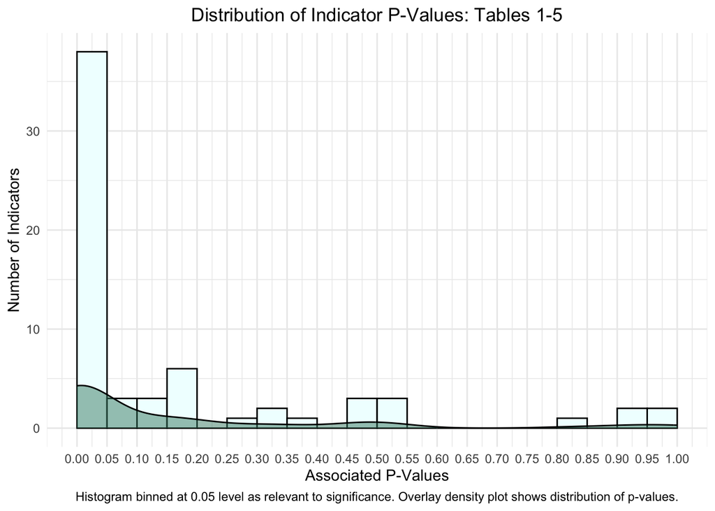

Summary P-Value Distribution

| Total Hypotheses | Number of Signficant Indicators | Percentage of Significant Indicators |
| --- | --- | --- |
| 65 | 38 | 58.46154 |

The distribution of p-values does not follow a uniform distribution, which we’d expected under the null. Over 58% have a p-value < 0.05. Under the null hypothesis this would be extremely rare , suggesting that these indicators do have some predictive signal among them.

*4. Construct Bonferroni p-values. Controlling the FWER at 5 percent, which predictors are significant? Which predictors lose their significance when you account for multiple testing using the Bonferroni correction?*

P-Value Significance after Bonferroni Adjustment

| Indicators | RR Coefficient | 95% CI | ChiSquared | P-Value | Bonferroni Adjusted P-Value |
| --- | --- | --- | --- | --- | --- |
| I-1. Presence of any type of violence carried out by the aggressor | 1.10 | [0.89-1.37] | 0.810 | 0.36812 | 1.00000 |
| I-2. Psychological Violence | 1.19 | [0.98-1.48] | 3.370 | 0.06639 | 1.00000 |
| I-3. Physical violence | 0.99 | [0.82-1.19] | 0.000 | 1.00000 | 1.00000 |
| I-4. Sexual violence | 1.14 | [0.80-1.62] | 0.520 | 0.47084 | 1.00000 |
| I-5. Victim’s defensive reaction to physical aggression | 1.11 | [0.92-1.35] | 1.234 | 0.26663 | 1.00000 |
| I-6. Use of weapons/objects against partner | 1.46 | [1.15-1.86]** | 9.510 | 0.00204 | 0.13283 |
| I-7. The aggressor has access to firearms | 1.13 | [0.78-1.63] | 0.430 | 0.51199 | 1.00000 |
| I-8. The aggressor is an expert in combat techniques | 1.37 | [0.85-2.21] | 1.710 | 0.19099 | 1.00000 |
| I-9. Presence of threats/plans aimed to cause the victim harm | 1.07 | [0.89-1.28] | 0.530 | 0.46661 | 1.00000 |
| I-10. An escalation in aggression or threats in the last 6 months | 1.32 | [1.11-1.58]** | 9.700 | 0.00184 | 0.11977 |
| I-11. They have shown exaggerated jealousy or have suspected their partner of infidelity in the last 6 months | 1.54 | [1.28-1.85]*** | 21.940 | 0.00000 | 0.00018 |
| I-12. They have shown controlling behaviors in the last 6 months | 1.80 | [1.49-2.18]*** | 38.360 | 0.00000 | 0.00000 |
| I-13. In the last 6 months they have shown harassing behaviors | 1.38 | [1.15-1.66]*** | 11.900 | 0.00056 | 0.03649 |
| I-14.In the last year they have done material damage | 1.30 | [1.07-1.57]** | 7.540 | 0.00603 | 0.39224 |
| I-15. In the last year they have disrespected an authority figure | 1.58 | [1.22-2.04]*** | 12.000 | 0.00053 | 0.03458 |
| I-16. In the last year they have committed an aggression against third parties and/or animals. | 1.31 | [1.01-1.71] | 4.180 | 0.04090 | 1.00000 |
| I-17. In the last year they have made threats and slights towards third parties. | 1.26 | [1.03-1.56] | 5.050 | 0.02463 | 1.00000 |
| I-18. Presence of problems in their life in the last 6 months. | 1.45 | [1.18-1.72]*** | 13.170 | 0.00028 | 0.01849 |
| I-19. Presence of a criminal record | 1.64 | [1.38-1.95]*** | 31.570 | 0.00000 | 0.00000 |
| I-20. Presence of past breakings of sentence conditions | 1.85 | [1.34-2.56]*** | 13.730 | 0.00021 | 0.01372 |
| I-21. Presence of physical/sexual aggression records | 1.58 | [1.28-1.96]*** | 18.360 | 0.00002 | 0.00119 |
| I-22. Presence of gender violence records against other partners | 1.44 | [1.15-1.80]*** | 10.290 | 0.00134 | 0.08694 |
| I-23. Presence of mental/psychiatric disorder | 1.27 | [0.89-1.80] | 1.810 | 0.17851 | 1.00000 |
| I-24. Presence of suicidal ideas or attempts | 1.67 | [1.32-2.13]*** | 17.550 | 0.00003 | 0.00182 |
| I-25. Presence of any type of addiction or substance abuse (alcohol and drugs) | 1.39 | [1.15-1.67]*** | 12.180 | 0.00048 | 0.03140 |
| I-26. Presence of a gender or domestic violence history within their family | 1.63 | [1.23-2.16]*** | 11.620 | 0.00065 | 0.04241 |
| I-27. Presence of any type of disability | 1.30 | [0.77-2.20] | 0.970 | 0.32468 | 1.00000 |
| I-28. Victim is in gestation period | 1.06 | [0.61-1.84] | 0.050 | 0.82306 | 1.00000 |
| I-29. Victim suffers from a serious illness | 1.00 | [0.55-1.84] | 0.000 | 1.00000 | 1.00000 |
| I-30. Victim is a foreigner | 0.73 | [0.58-0.92]** | 6.980 | 0.00824 | 0.53577 |
| I-31. Victim has no social/family support | 0.98 | [0.76-1.26] | 0.010 | 0.92034 | 1.00000 |
| I-32. Victim has a mental/psychiatric disorder | 0.82 | [0.49-1.38] | 0.530 | 0.46661 | 1.00000 |
| I-33. Victim has suicidal ideas/attempts | 1.34 | [0.87-2.05] | 1.810 | 0.17851 | 1.00000 |
| I-34. Victim has any kind of addiction or engages in substance abuse (alcohol and drugs) | 1.23 | [0.82-1.84] | 1.020 | 0.31252 | 1.00000 |
| I-35. There is a history of gender or domestic violence within their family | 1.40 | [0.91-2.15] | 2.390 | 0.12211 | 1.00000 |
| I-36. Victim is economically dependent on the aggressor | 0.86 | [0.69-1.07] | 1.690 | 0.19360 | 1.00000 |
| I-37. Victim has minors or family members under their care | 1.05 | [0.89-1.25] | 0.400 | 0.52709 | 1.00000 |
| I-38. The victim has withdrawn complaints in the past | 1.13 | [0.78-1.62] | 0.430 | 0.51199 | 1.00000 |
| I-39. The victim has suffered gender violence by the hands of other aggressors in the past | 1.39 | [1.07-1.81] | 6.290 | 0.01214 | 0.78924 |
| I-40. The victim has expressed their desire to end the relationship to the aggressor at least 6 months ago | 1.48 | [1.22-1.79]*** | 16.420 | 0.00005 | 0.00330 |
| I-41. There have been reports of mutual violence | 1.01 | [0.77-1.32] | 0.010 | 0.92034 | 1.00000 |
| I-42. The victim fears for the physical integrity of the minors or family members under their care | 1.20 | [0.97-1.42] | 2.980 | 0.08430 | 1.00000 |
| I-43. The victim thinks that the aggressor is capable of attacking them in a violent way or even of killing them | 1.33 | [1.10-1.61]** | 9.180 | 0.00245 | 0.15904 |
| I-1. The aggressor has contacted the victim through technological means | 6.69 | [4.43-10.10]*** | 106.820 | 0.00000 | 0.00000 |
| I-2. The aggressor has contacted the victim through third parties | 1.60 | [0.91-2.83] | 2.750 | 0.09725 | 1.00000 |
| I-3. The aggressor has physically gotten closer to the victim | 11.99 | [8.47-16.96]*** | 295.670 | 0.00000 | 0.00000 |
| I-4. The aggressor is an escaped convict or is in an unknown location | 1.82 | [1.06-3.11] | 4.980 | 0.02564 | 1.00000 |
| I-5. The aggressor has distanced themselves from the victim | 0.06 | [0.05-0.08]*** | 551.820 | 0.00000 | 0.00000 |
| I-6. The aggressor shows a peaceful attitude | 0.09 | [0.06-0.11]*** | 417.630 | 0.00000 | 0.00000 |
| I-7. The aggressor exteriorizes a respectful attitude toward the law | 0.18 | [0.14-0.24]*** | 166.580 | 0.00000 | 0.00000 |
| I-8. The aggressor shows regret | 0.28 | [0.20-0.41]*** | 52.280 | 0.00000 | 0.00000 |
| I-9. The aggressor joins Help programs | 0.33 | [0.19-0.57]*** | 17.200 | 0.00003 | 0.00219 |
| I-10. The aggressor follows the requirements of the charges and of the family separation | 0.26 | [0.17-0.39]*** | 48.000 | 0.00000 | 0.00000 |
| I-11. The victim has resumed living with the aggressor | 4.36 | [2.67-7.12]*** | 41.160 | 0.00000 | 0.00000 |
| I-12. The victim doesn’t report any episodes to file a complaint about, and/or turns down the offer of protection | 2.85 | [2.09-3.88]*** | 48.180 | 0.00000 | 0.00000 |
| I-13. The victim engages in activities that threaten their own security | 6.15 | [4.37-8.64]*** | 138.080 | 0.00000 | 0.00000 |
| I-14. The victim is in a situation of economical dependency | 1.26 | [0.90-1.77] | 1.940 | 0.16367 | 1.00000 |
| I-15. The victim has minors or family member under their care | 1.22 | [0.94-1.58] | 2.270 | 0.13190 | 1.00000 |
| I-16. Judicial proceedings to carry out a separation/divorce unwanted by the aggressor | 1.52 | [1.11-2.08]** | 6.950 | 0.00838 | 0.54483 |
| I-17. The victim establishes a new sentimental relationship, which is not approved by the aggressor | 1.41 | [0.85-2.33] | 1.860 | 0.17262 | 1.00000 |
| I-18. The aggressor establishes a new sentimental relationship | 1.41 | [0.90-2.21] | 2.290 | 0.13021 | 1.00000 |
| I-19. The aggressor has a stable economic and labor situation | 0.63 | [0.47-0.85]** | 9.150 | 0.00249 | 0.16167 |
| I-20. The aggressor has favorable family and social support | 0.58 | [0.42-0.82]** | 9.870 | 0.00168 | 0.10920 |
| I-21. Presence of a conflict about their responsibilities in the children’s care | 2.74 | [2.00-3.75]*** | 42.990 | 0.00000 | 0.00000 |
| I-22. The victim feels that the risk level is nonexistent | 0.29 | [0.19-0.44]*** | 36.380 | 0.00000 | 0.00000 |

Note:  
Green Indicators: Lost significance after Bonferroni correction, Purple P-Values: Significant at 0.05 level, Orange Bonferroni Adjust P-Value: Significant at 0.05 level

The above table shows 13 indicators, highlighted in green, which had significant p-values (“P-Value” column cells highlighted in purple, <0.05) but do not after the Bonferroni adjustment. There are 25 indicators which have statistically significant Bonferroni-adjusted p-values (“Bonferroni Adjusted P-Value” column cells highlighted in orange, <0.05).

*5. Now test for significance using the Benjamini-Hochberg approach, controlling the FDR at 5 percent. Produce a useful visualization that illustrates how the procedure works.*

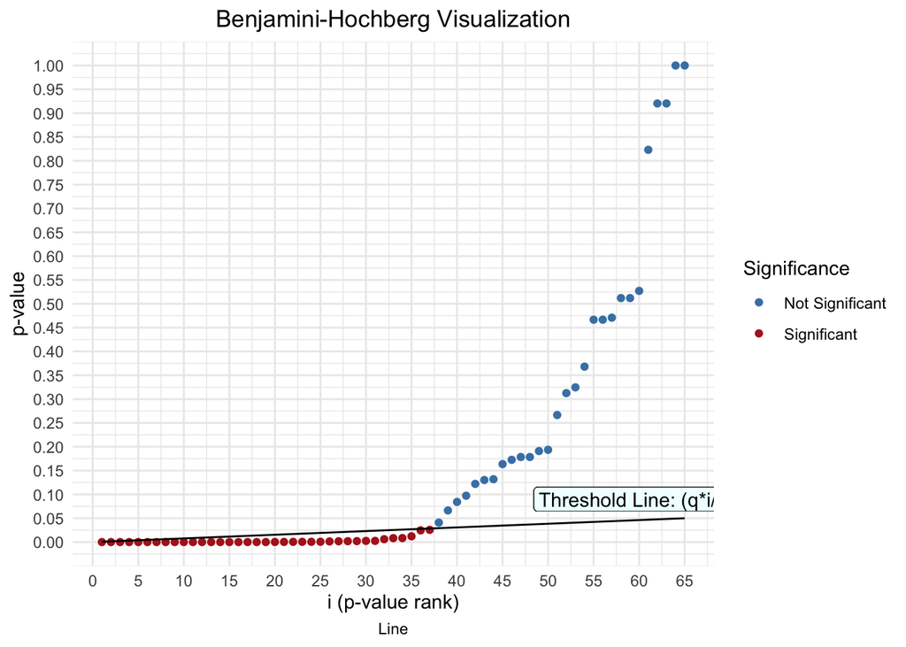

Benjamini-Hochberg Significant Indicators

| Indicators | P-Value | P-Value Rank (i) | Threshold (q*i/m) |
| --- | --- | --- | --- |
| I-5. The aggressor has distanced themselves from the victim | 0.0000000 | 1 | 0.0007692 |
| I-6. The aggressor shows a peaceful attitude | 0.0000000 | 2 | 0.0015385 |
| I-3. The aggressor has physically gotten closer to the victim | 0.0000000 | 3 | 0.0023077 |
| I-7. The aggressor exteriorizes a respectful attitude toward the law | 0.0000000 | 4 | 0.0030769 |
| I-13. The victim engages in activities that threaten their own security | 0.0000000 | 5 | 0.0038462 |
| I-1. The aggressor has contacted the victim through technological means | 0.0000000 | 6 | 0.0046154 |
| I-8. The aggressor shows regret | 0.0000000 | 7 | 0.0053846 |
| I-12. The victim doesn’t report any episodes to file a complaint about, and/or turns down the offer of protection | 0.0000000 | 8 | 0.0061538 |
| I-10. The aggressor follows the requirements of the charges and of the family separation | 0.0000000 | 9 | 0.0069231 |
| I-21. Presence of a conflict about their responsibilities in the children’s care | 0.0000000 | 10 | 0.0076923 |
| I-11. The victim has resumed living with the aggressor | 0.0000000 | 11 | 0.0084615 |
| I-12. They have shown controlling behaviors in the last 6 months | 0.0000000 | 12 | 0.0092308 |
| I-22. The victim feels that the risk level is nonexistent | 0.0000000 | 13 | 0.0100000 |
| I-19. Presence of a criminal record | 0.0000000 | 14 | 0.0107692 |
| I-11. They have shown exaggerated jealousy or have suspected their partner of infidelity in the last 6 months | 0.0000028 | 15 | 0.0115385 |
| I-21. Presence of physical/sexual aggression records | 0.0000183 | 16 | 0.0123077 |
| I-24. Presence of suicidal ideas or attempts | 0.0000280 | 17 | 0.0130769 |
| I-9. The aggressor joins Help programs | 0.0000336 | 18 | 0.0138462 |
| I-40. The victim has expressed their desire to end the relationship to the aggressor at least 6 months ago | 0.0000507 | 19 | 0.0146154 |
| I-20. Presence of past breakings of sentence conditions | 0.0002111 | 20 | 0.0153846 |
| I-18. Presence of problems in their life in the last 6 months. | 0.0002845 | 21 | 0.0161538 |
| I-25. Presence of any type of addiction or substance abuse (alcohol and drugs) | 0.0004830 | 22 | 0.0169231 |
| I-15. In the last year they have disrespected an authority figure | 0.0005320 | 23 | 0.0176923 |
| I-13. In the last 6 months they have shown harassing behaviors | 0.0005613 | 24 | 0.0184615 |
| I-26. Presence of a gender or domestic violence history within their family | 0.0006525 | 25 | 0.0192308 |
| I-22. Presence of gender violence records against other partners | 0.0013375 | 26 | 0.0200000 |
| I-20. The aggressor has favorable family and social support | 0.0016800 | 27 | 0.0207692 |
| I-10. An escalation in aggression or threats in the last 6 months | 0.0018427 | 28 | 0.0215385 |
| I-6. Use of weapons/objects against partner | 0.0020436 | 29 | 0.0223077 |
| I-43. The victim thinks that the aggressor is capable of attacking them in a violent way or even of killing them | 0.0024467 | 30 | 0.0230769 |
| I-19. The aggressor has a stable economic and labor situation | 0.0024872 | 31 | 0.0238462 |
| I-14.In the last year they have done material damage | 0.0060344 | 32 | 0.0246154 |
| I-30. Victim is a foreigner | 0.0082426 | 33 | 0.0253846 |
| I-16. Judicial proceedings to carry out a separation/divorce unwanted by the aggressor | 0.0083819 | 34 | 0.0261538 |
| I-39. The victim has suffered gender violence by the hands of other aggressors in the past | 0.0121421 | 35 | 0.0269231 |
| I-17. In the last year they have made threats and slights towards third parties. | 0.0246259 | 36 | 0.0276923 |
| I-4. The aggressor is an escaped convict or is in an unknown location | 0.0256420 | 37 | 0.0284615 |

*5. (Cont.) According to this criterion, how many of the features are significant? In expectation, how many of these are false discoveries?*

According to this criterion, 37 of these indicators are significant. We expect 5% of these 37 indicators to be false discoveries; therefore, we assume 1.85 indicators are false discoveries.

6. Compute the probability that each test represents a false discovery. This requires solving one equation in one unknown for each test.

| Indicators | P-Value | P-Value Rank (i) | Threshold (q*i/m) | Probability of False Discovery |
| --- | --- | --- | --- | --- |
| I-5. The aggressor has distanced themselves from the victim | 0.0000000 | 1 | 0.0007692 | 0.0000000 |
| I-6. The aggressor shows a peaceful attitude | 0.0000000 | 2 | 0.0015385 | 0.0000000 |
| I-3. The aggressor has physically gotten closer to the victim | 0.0000000 | 3 | 0.0023077 | 0.0000000 |
| I-7. The aggressor exteriorizes a respectful attitude toward the law | 0.0000000 | 4 | 0.0030769 | 0.0000000 |
| I-13. The victim engages in activities that threaten their own security | 0.0000000 | 5 | 0.0038462 | 0.0000000 |
| I-1. The aggressor has contacted the victim through technological means | 0.0000000 | 6 | 0.0046154 | 0.0000000 |
| I-8. The aggressor shows regret | 0.0000000 | 7 | 0.0053846 | 0.0000000 |
| I-12. The victim doesn’t report any episodes to file a complaint about, and/or turns down the offer of protection | 0.0000000 | 8 | 0.0061538 | 0.0000000 |
| I-10. The aggressor follows the requirements of the charges and of the family separation | 0.0000000 | 9 | 0.0069231 | 0.0000000 |
| I-21. Presence of a conflict about their responsibilities in the children’s care | 0.0000000 | 10 | 0.0076923 | 0.0000000 |
| I-11. The victim has resumed living with the aggressor | 0.0000000 | 11 | 0.0084615 | 0.0000000 |
| I-12. They have shown controlling behaviors in the last 6 months | 0.0000000 | 12 | 0.0092308 | 0.0000000 |
| I-22. The victim feels that the risk level is nonexistent | 0.0000000 | 13 | 0.0100000 | 0.0000000 |
| I-19. Presence of a criminal record | 0.0000000 | 14 | 0.0107692 | 0.0000001 |
| I-11. They have shown exaggerated jealousy or have suspected their partner of infidelity in the last 6 months | 0.0000028 | 15 | 0.0115385 | 0.0000122 |
| I-21. Presence of physical/sexual aggression records | 0.0000183 | 16 | 0.0123077 | 0.0000743 |
| I-24. Presence of suicidal ideas or attempts | 0.0000280 | 17 | 0.0130769 | 0.0001070 |
| I-9. The aggressor joins Help programs | 0.0000336 | 18 | 0.0138462 | 0.0001215 |
| I-40. The victim has expressed their desire to end the relationship to the aggressor at least 6 months ago | 0.0000507 | 19 | 0.0146154 | 0.0001736 |
| I-20. Presence of past breakings of sentence conditions | 0.0002111 | 20 | 0.0153846 | 0.0006859 |
| I-18. Presence of problems in their life in the last 6 months. | 0.0002845 | 21 | 0.0161538 | 0.0008805 |
| I-25. Presence of any type of addiction or substance abuse (alcohol and drugs) | 0.0004830 | 22 | 0.0169231 | 0.0014272 |
| I-15. In the last year they have disrespected an authority figure | 0.0005320 | 23 | 0.0176923 | 0.0015035 |
| I-13. In the last 6 months they have shown harassing behaviors | 0.0005613 | 24 | 0.0184615 | 0.0015203 |
| I-26. Presence of a gender or domestic violence history within their family | 0.0006525 | 25 | 0.0192308 | 0.0016964 |
| I-22. Presence of gender violence records against other partners | 0.0013375 | 26 | 0.0200000 | 0.0033438 |
| I-20. The aggressor has favorable family and social support | 0.0016800 | 27 | 0.0207692 | 0.0040443 |
| I-10. An escalation in aggression or threats in the last 6 months | 0.0018427 | 28 | 0.0215385 | 0.0042777 |
| I-6. Use of weapons/objects against partner | 0.0020436 | 29 | 0.0223077 | 0.0045804 |
| I-43. The victim thinks that the aggressor is capable of attacking them in a violent way or even of killing them | 0.0024467 | 30 | 0.0230769 | 0.0052151 |
| I-19. The aggressor has a stable economic and labor situation | 0.0024872 | 31 | 0.0238462 | 0.0052151 |
| I-14.In the last year they have done material damage | 0.0060344 | 32 | 0.0246154 | 0.0122574 |
| I-30. Victim is a foreigner | 0.0082426 | 33 | 0.0253846 | 0.0160243 |
| I-16. Judicial proceedings to carry out a separation/divorce unwanted by the aggressor | 0.0083819 | 34 | 0.0261538 | 0.0160243 |
| I-39. The victim has suffered gender violence by the hands of other aggressors in the past | 0.0121421 | 35 | 0.0269231 | 0.0225496 |
| I-17. In the last year they have made threats and slights towards third parties. | 0.0246259 | 36 | 0.0276923 | 0.0444635 |
| I-4. The aggressor is an escaped convict or is in an unknown location | 0.0256420 | 37 | 0.0284615 | 0.0450467 |
| I-16. In the last year they have committed an aggression against third parties and/or animals. | 0.0409037 | 38 | 0.0292308 | 0.0699669 |
| I-2. Psychological Violence | 0.0663938 | 39 | 0.0300000 | 0.1106563 |
| I-42. The victim fears for the physical integrity of the minors or family members under their care | 0.0842993 | 40 | 0.0307692 | 0.1369863 |
| I-2. The aggressor has contacted the victim through third parties | 0.0972544 | 41 | 0.0315385 | 0.1541838 |
| I-35. There is a history of gender or domestic violence within their family | 0.1221136 | 42 | 0.0323077 | 0.1889854 |
| I-18. The aggressor establishes a new sentimental relationship | 0.1302099 | 43 | 0.0330769 | 0.1948521 |
| I-15. The victim has minors or family member under their care | 0.1318999 | 44 | 0.0338462 | 0.1948521 |
| I-14. The victim is in a situation of economical dependency | 0.1636685 | 45 | 0.0346154 | 0.2364101 |
| I-17. The victim establishes a new sentimental relationship, which is not approved by the aggressor | 0.1726248 | 46 | 0.0353846 | 0.2417299 |
| I-33. Victim has suicidal ideas/attempts | 0.1785082 | 47 | 0.0361538 | 0.2417299 |
| I-23. Presence of mental/psychiatric disorder | 0.1785082 | 48 | 0.0369231 | 0.2417299 |
| I-8. The aggressor is an expert in combat techniques | 0.1909854 | 49 | 0.0376923 | 0.2516813 |
| I-36. Victim is economically dependent on the aggressor | 0.1936010 | 50 | 0.0384615 | 0.2516813 |
| I-5. Victim’s defensive reaction to physical aggression | 0.2666305 | 51 | 0.0392308 | 0.3398232 |
| I-34. Victim has any kind of addiction or engages in substance abuse (alcohol and drugs) | 0.3125190 | 52 | 0.0400000 | 0.3906488 |
| I-27. Presence of any type of disability | 0.3246802 | 53 | 0.0407692 | 0.3981927 |
| I-1. Presence of any type of violence carried out by the aggressor | 0.3681203 | 54 | 0.0415385 | 0.4431077 |
| I-32. Victim has a mental/psychiatric disorder | 0.4666069 | 55 | 0.0423077 | 0.5369247 |
| I-9. Presence of threats/plans aimed to cause the victim harm | 0.4666069 | 56 | 0.0430769 | 0.5369247 |
| I-4. Sexual violence | 0.4708417 | 57 | 0.0438462 | 0.5369247 |
| I-38. The victim has withdrawn complaints in the past | 0.5119889 | 58 | 0.0446154 | 0.5640556 |
| I-7. The aggressor has access to firearms | 0.5119889 | 59 | 0.0453846 | 0.5640556 |
| I-37. Victim has minors or family members under their care | 0.5270893 | 60 | 0.0461538 | 0.5710134 |
| I-28. Victim is in gestation period | 0.8230633 | 61 | 0.0469231 | 0.8770346 |
| I-41. There have been reports of mutual violence | 0.9203443 | 62 | 0.0476923 | 0.9495616 |
| I-31. Victim has no social/family support | 0.9203443 | 63 | 0.0484615 | 0.9495616 |
| I-29. Victim suffers from a serious illness | 1.0000000 | 64 | 0.0492308 | 1.0000000 |
| I-3. Physical violence | 1.0000000 | 65 | 0.0500000 | 1.0000000 |

*7. Produce a concise listing of the predictors and the various test results indicating which of them are significant according to the various testing procedures. Also show which are not significant according to any test.*

Indicators and Corresponding Significance

| Indicators | RR | CI | ChiSq | Present | Absent | N/S | PerValid | OriginTable | pval | bonf | prank | qim | qadjp |
| --- | --- | --- | --- | --- | --- | --- | --- | --- | --- | --- | --- | --- | --- |
| I-5. The aggressor has distanced themselves from the victim | 0.06 | [0.05-0.08]*** | 551.820 | 3399 | 574 | 0 | 100.0 | 5 | 0.00000 | 0.00000 | 1 | 0.0007692 | 0.00000 |
| I-6. The aggressor shows a peaceful attitude | 0.09 | [0.06-0.11]*** | 417.630 | 3368 | 605 | 0 | 100.0 | 5 | 0.00000 | 0.00000 | 2 | 0.0015385 | 0.00000 |
| I-3. The aggressor has physically gotten closer to the victim | 11.99 | [8.47-16.96]*** | 295.670 | 208 | 3461 | 304 | 92.3 | 5 | 0.00000 | 0.00000 | 3 | 0.0023077 | 0.00000 |
| I-7. The aggressor exteriorizes a respectful attitude toward the law | 0.18 | [0.14-0.24]*** | 166.580 | 3523 | 450 | 0 | 100.0 | 5 | 0.00000 | 0.00000 | 4 | 0.0030769 | 0.00000 |
| I-13. The victim engages in activities that threaten their own security | 6.15 | [4.37-8.64]*** | 138.080 | 217 | 3756 | 0 | 100.0 | 5 | 0.00000 | 0.00000 | 5 | 0.0038462 | 0.00000 |
| I-1. The aggressor has contacted the victim through technological means | 6.69 | [4.43-10.10]*** | 106.820 | 155 | 3499 | 319 | 92.0 | 5 | 0.00000 | 0.00000 | 6 | 0.0046154 | 0.00000 |
| I-8. The aggressor shows regret | 0.28 | [0.20-0.41]*** | 52.280 | 1199 | 767 | 2007 | 49.5 | 5 | 0.00000 | 0.00000 | 7 | 0.0053846 | 0.00000 |
| I-12. The victim doesn’t report any episodes to file a complaint about, and/or turns down the offer of protection | 2.85 | [2.09-3.88]*** | 48.180 | 447 | 3526 | 0 | 100.0 | 5 | 0.00000 | 0.00000 | 8 | 0.0061538 | 0.00000 |
| I-10. The aggressor follows the requirements of the charges and of the family separation | 0.26 | [0.17-0.39]*** | 48.000 | 2009 | 534 | 1430 | 64.0 | 5 | 0.00000 | 0.00000 | 9 | 0.0069231 | 0.00000 |
| I-21. Presence of a conflict about their responsibilities in the children’s care | 2.74 | [2.00-3.75]*** | 42.990 | 522 | 2980 | 471 | 88.1 | 5 | 0.00000 | 0.00000 | 10 | 0.0076923 | 0.00000 |
| I-11. The victim has resumed living with the aggressor | 4.36 | [2.67-7.12]*** | 41.160 | 104 | 3869 | 0 | 100.0 | 5 | 0.00000 | 0.00000 | 11 | 0.0084615 | 0.00000 |
| I-12. They have shown controlling behaviors in the last 6 months | 1.80 | [1.49-2.18]*** | 38.360 | 2979 | 2991 | 643 | 90.3 | 2 | 0.00000 | 0.00000 | 12 | 0.0092308 | 0.00000 |
| I-22. The victim feels that the risk level is nonexistent | 0.29 | [0.19-0.44]*** | 36.380 | 990 | 2512 | 471 | 88.1 | 5 | 0.00000 | 0.00000 | 13 | 0.0100000 | 0.00000 |
| I-19. Presence of a criminal record | 1.64 | [1.38-1.95]*** | 31.570 | 2581 | 3729 | 303 | 95.4 | 2 | 0.00000 | 0.00000 | 14 | 0.0107692 | 0.00000 |
| I-11. They have shown exaggerated jealousy or have suspected their partner of infidelity in the last 6 months | 1.54 | [1.28-1.85]*** | 21.940 | 2748 | 3255 | 610 | 90.8 | 2 | 0.00000 | 0.00018 | 15 | 0.0115385 | 0.00001 |
| I-21. Presence of physical/sexual aggression records | 1.58 | [1.28-1.96]*** | 18.360 | 934 | 5239 | 440 | 93.3 | 2 | 0.00002 | 0.00119 | 16 | 0.0123077 | 0.00007 |
| I-24. Presence of suicidal ideas or attempts | 1.67 | [1.32-2.13]*** | 17.550 | 625 | 5292 | 696 | 89.5 | 2 | 0.00003 | 0.00182 | 17 | 0.0130769 | 0.00011 |
| I-9. The aggressor joins Help programs | 0.33 | [0.19-0.57]*** | 17.200 | 500 | 1318 | 2155 | 45.8 | 5 | 0.00003 | 0.00219 | 18 | 0.0138462 | 0.00012 |
| I-40. The victim has expressed their desire to end the relationship to the aggressor at least 6 months ago | 1.48 | [1.22-1.79]*** | 16.420 | 3373 | 2610 | 630 | 90.5 | 4 | 0.00005 | 0.00330 | 19 | 0.0146154 | 0.00017 |
| I-20. Presence of past breakings of sentence conditions | 1.85 | [1.34-2.56]*** | 13.730 | 267 | 5901 | 445 | 93.3 | 2 | 0.00021 | 0.01372 | 20 | 0.0153846 | 0.00069 |
| I-18. Presence of problems in their life in the last 6 months. | 1.45 | [1.18-1.72]*** | 13.170 | 1482 | 3648 | 1483 | 77.6 | 2 | 0.00028 | 0.01849 | 21 | 0.0161538 | 0.00088 |
| I-25. Presence of any type of addiction or substance abuse (alcohol and drugs) | 1.39 | [1.15-1.67]*** | 12.180 | 2499 | 3231 | 883 | 86.6 | 2 | 0.00048 | 0.03140 | 22 | 0.0169231 | 0.00143 |
| I-15. In the last year they have disrespected an authority figure | 1.58 | [1.22-2.04]*** | 12.000 | 572 | 5353 | 688 | 89.6 | 2 | 0.00053 | 0.03458 | 23 | 0.0176923 | 0.00150 |
| I-13. In the last 6 months they have shown harassing behaviors | 1.38 | [1.15-1.66]*** | 11.900 | 2149 | 3765 | 699 | 89.4 | 2 | 0.00056 | 0.03649 | 24 | 0.0184615 | 0.00152 |
| I-26. Presence of a gender or domestic violence history within their family | 1.63 | [1.23-2.16]*** | 11.620 | 547 | 3701 | 2365 | 64.2 | 2 | 0.00065 | 0.04241 | 25 | 0.0192308 | 0.00170 |
| I-22. Presence of gender violence records against other partners | 1.44 | [1.15-1.80]*** | 10.290 | 861 | 5322 | 430 | 93.5 | 2 | 0.00134 | 0.08694 | 26 | 0.0200000 | 0.00334 |
| I-20. The aggressor has favorable family and social support | 0.58 | [0.42-0.82]** | 9.870 | 2070 | 690 | 1213 | 69.5 | 5 | 0.00168 | 0.10920 | 27 | 0.0207692 | 0.00404 |
| I-10. An escalation in aggression or threats in the last 6 months | 1.32 | [1.11-1.58]** | 9.700 | 2640 | 3398 | 575 | 91.3 | 1 | 0.00184 | 0.11977 | 28 | 0.0215385 | 0.00428 |
| I-6. Use of weapons/objects against partner | 1.46 | [1.15-1.86]** | 9.510 | 673 | 5813 | 127 | 98.1 | 1 | 0.00204 | 0.13283 | 29 | 0.0223077 | 0.00458 |
| I-43. The victim thinks that the aggressor is capable of attacking them in a violent way or even of killing them | 1.33 | [1.10-1.61]** | 9.180 | 2020 | 3510 | 1083 | 83.6 | 4 | 0.00245 | 0.15904 | 30 | 0.0230769 | 0.00522 |
| I-19. The aggressor has a stable economic and labor situation | 0.63 | [0.47-0.85]** | 9.150 | 1823 | 1327 | 0 | 79.3 | 5 | 0.00249 | 0.16167 | 31 | 0.0238462 | 0.00522 |
| I-14.In the last year they have done material damage | 1.30 | [1.07-1.57]** | 7.540 | 1774 | 4290 | 549 | 91.7 | 2 | 0.00603 | 0.39224 | 32 | 0.0246154 | 0.01226 |
| I-30. Victim is a foreigner | 0.73 | [0.58-0.92]** | 6.980 | 1698 | 4862 | 53 | 99.2 | 3 | 0.00824 | 0.53577 | 33 | 0.0253846 | 0.01602 |
| I-16. Judicial proceedings to carry out a separation/divorce unwanted by the aggressor | 1.52 | [1.11-2.08]** | 6.950 | 635 | 3338 | 0 | 100.0 | 5 | 0.00838 | 0.54483 | 34 | 0.0261538 | 0.01602 |
| I-39. The victim has suffered gender violence by the hands of other aggressors in the past | 1.39 | [1.07-1.81] | 6.290 | 619 | 5504 | 490 | 92.6 | 4 | 0.01214 | 0.78924 | 35 | 0.0269231 | 0.02255 |
| I-17. In the last year they have made threats and slights towards third parties. | 1.26 | [1.03-1.56] | 5.050 | 1344 | 4385 | 884 | 86.6 | 2 | 0.02463 | 1.00000 | 36 | 0.0276923 | 0.04446 |
| I-4. The aggressor is an escaped convict or is in an unknown location | 1.82 | [1.06-3.11] | 4.980 | 153 | 3820 | 0 | 100.0 | 5 | 0.02564 | 1.00000 | 37 | 0.0284615 | 0.04505 |
| I-16. In the last year they have committed an aggression against third parties and/or animals. | 1.31 | [1.01-1.71] | 4.180 | 687 | 5143 | 783 | 88.2 | 2 | 0.04090 | 1.00000 | 38 | 0.0292308 | 0.06997 |
| I-2. Psychological Violence | 1.19 | [0.98-1.48] | 3.370 | 4115 | 2204 | 294 | 95.6 | 1 | 0.06639 | 1.00000 | 39 | 0.0300000 | 0.11066 |
| I-42. The victim fears for the physical integrity of the minors or family members under their care | 1.20 | [0.97-1.42] | 2.980 | 1186 | 5427 | 0 | 100.0 | 4 | 0.08430 | 1.00000 | 40 | 0.0307692 | 0.13699 |
| I-2. The aggressor has contacted the victim through third parties | 1.60 | [0.91-2.83] | 2.750 | 188 | 3463 | 322 | 91.9 | 5 | 0.09725 | 1.00000 | 41 | 0.0315385 | 0.15418 |
| I-35. There is a history of gender or domestic violence within their family | 1.40 | [0.91-2.15] | 2.390 | 205 | 5504 | 904 | 86.3 | 3 | 0.12211 | 1.00000 | 42 | 0.0323077 | 0.18899 |
| I-18. The aggressor establishes a new sentimental relationship | 1.41 | [0.90-2.21] | 2.290 | 268 | 2383 | 1322 | 66.7 | 5 | 0.13021 | 1.00000 | 43 | 0.0330769 | 0.19485 |
| I-15. The victim has minors or family member under their care | 1.22 | [0.94-1.58] | 2.270 | 2125 | 1848 | 0 | 100.0 | 5 | 0.13190 | 1.00000 | 44 | 0.0338462 | 0.19485 |
| I-14. The victim is in a situation of economical dependency | 1.26 | [0.90-1.77] | 1.940 | 604 | 3369 | 0 | 100.0 | 5 | 0.16367 | 1.00000 | 45 | 0.0346154 | 0.23641 |
| I-17. The victim establishes a new sentimental relationship, which is not approved by the aggressor | 1.41 | [0.85-2.33] | 1.860 | 215 | 3758 | 0 | 100.0 | 5 | 0.17262 | 1.00000 | 46 | 0.0353846 | 0.24173 |
| I-33. Victim has suicidal ideas/attempts | 1.34 | [0.87-2.05] | 1.810 | 206 | 6036 | 371 | 94.4 | 3 | 0.17851 | 1.00000 | 47 | 0.0361538 | 0.24173 |
| I-23. Presence of mental/psychiatric disorder | 1.27 | [0.89-1.80] | 1.810 | 343 | 5328 | 942 | 85.8 | 2 | 0.17851 | 1.00000 | 48 | 0.0369231 | 0.24173 |
| I-8. The aggressor is an expert in combat techniques | 1.37 | [0.85-2.21] | 1.710 | 164 | 5351 | 1098 | 83.4 | 1 | 0.19099 | 1.00000 | 49 | 0.0376923 | 0.25168 |
| I-36. Victim is economically dependent on the aggressor | 0.86 | [0.69-1.07] | 1.690 | 1446 | 4537 | 630 | 90.5 | 3 | 0.19360 | 1.00000 | 50 | 0.0384615 | 0.25168 |
| I-5. Victim’s defensive reaction to physical aggression | 1.11 | [0.92-1.35] | 1.234 | 1718 | 4305 | 590 | 91.1 | 1 | 0.26663 | 1.00000 | 51 | 0.0392308 | 0.33982 |
| I-34. Victim has any kind of addiction or engages in substance abuse (alcohol and drugs) | 1.23 | [0.82-1.84] | 1.020 | 260 | 5753 | 600 | 90.9 | 3 | 0.31252 | 1.00000 | 52 | 0.0400000 | 0.39065 |
| I-27. Presence of any type of disability | 1.30 | [0.77-2.20] | 0.970 | 136 | 6310 | 167 | 97.5 | 3 | 0.32468 | 1.00000 | 53 | 0.0407692 | 0.39819 |
| I-1. Presence of any type of violence carried out by the aggressor | 1.10 | [0.89-1.37] | 0.810 | 5139 | 1404 | 70 | 98.9 | 1 | 0.36812 | 1.00000 | 54 | 0.0415385 | 0.44311 |
| I-32. Victim has a mental/psychiatric disorder | 0.82 | [0.49-1.38] | 0.530 | 230 | 5963 | 420 | 93.6 | 3 | 0.46661 | 1.00000 | 55 | 0.0423077 | 0.53692 |
| I-9. Presence of threats/plans aimed to cause the victim harm | 1.07 | [0.89-1.28] | 0.530 | 3954 | 2274 | 385 | 94.2 | 1 | 0.46661 | 1.00000 | 56 | 0.0430769 | 0.53692 |
| I-4. Sexual violence | 1.14 | [0.80-1.62] | 0.520 | 360 | 5942 | 311 | 95.3 | 1 | 0.47084 | 1.00000 | 57 | 0.0438462 | 0.53692 |
| I-38. The victim has withdrawn complaints in the past | 1.13 | [0.78-1.62] | 0.430 | 352 | 5953 | 308 | 95.3 | 4 | 0.51199 | 1.00000 | 58 | 0.0446154 | 0.56406 |
| I-7. The aggressor has access to firearms | 1.13 | [0.78-1.63] | 0.430 | 347 | 5484 | 782 | 88.2 | 1 | 0.51199 | 1.00000 | 59 | 0.0453846 | 0.56406 |
| I-37. Victim has minors or family members under their care | 1.05 | [0.89-1.25] | 0.400 | 3661 | 2952 | 0 | 100.0 | 3 | 0.52709 | 1.00000 | 60 | 0.0461538 | 0.57101 |
| I-28. Victim is in gestation period | 1.06 | [0.61-1.84] | 0.050 | 154 | 6255 | 204 | 96.9 | 3 | 0.82306 | 1.00000 | 61 | 0.0469231 | 0.87703 |
| I-41. There have been reports of mutual violence | 1.01 | [0.77-1.32] | 0.010 | 834 | 5004 | 775 | 88.3 | 4 | 0.92034 | 1.00000 | 62 | 0.0476923 | 0.94956 |
| I-31. Victim has no social/family support | 0.98 | [0.76-1.26] | 0.010 | 903 | 5104 | 606 | 90.8 | 3 | 0.92034 | 1.00000 | 63 | 0.0484615 | 0.94956 |
| I-29. Victim suffers from a serious illness | 1.00 | [0.55-1.84] | 0.000 | 137 | 6185 | 291 | 95.6 | 3 | 1.00000 | 1.00000 | 64 | 0.0492308 | 1.00000 |
| I-3. Physical violence | 0.99 | [0.82-1.19] | 0.000 | 4369 | 2150 | 94 | 98.6 | 1 | 1.00000 | 1.00000 | 65 | 0.0500000 | 1.00000 |

Note:  
Original P-Value: Purple = Significant, Bonferroni Adjusted P-Value: Orange = Significant, Bonferroni Adjusted P-Value: Green = Significant, alpha = 0.05

When ordering by original p-value, the first 25 tests are significant (<0.05) under all 3 procedures. Ranked tests 26-37 are significant according to the original p-value and the Benjamini-Hochberg approach. Ranked test 38 is only significant according to the original p-value. All ranked tests 39 and higher are not significant under any test at the 0.05 level.

*7. Cont. Do the most- or least-significant predictors follow any pattern? What about those in between, i.e., those which are significant according to some procedures but not others?*

The most-significant predictors, in particular the first 11, are all from table 5 (the VPER 2015 form). Upon first glance, these top 11 indicators appear to have very different strengths. For example, the Risk Ratio coefficients of I-5 and I-6 are less than 0.10; but I-3, I-13, and I-1 are all greater than 6.10. This is explained in the original Table 5 note, which states “Protection when values are inferior to 1 and risk when they are superior to 1” – which follows as indicators I-5 and I-6 are “protective,” while the others are “risks”. All “protective” indicators are significant by at least one procedure.

All of the least significant indicators have coefficients closer to 1, and a Chi-Squared value equal to or very close to 0. This confirms that there is little to no relationship between the indicator and outcome, thus appropriately confirming the null hypothesis of no-relation (p-value > 0.05, and in fact = 1).

Under the Bonferroni adjustment, every adjusted p-value at or above rank 36 is equal to 1. There are thus 2-3 indicators which other procedures would confirm are significant, but which Bonferroni suggests absolutely prove the null hypothesis. This makes sense as the Bonferonni adjustment is much more conservative, minimizing the risk of Type I error but ultimately increasing the risk of Type II error as a result.

8. Considering the objectives of the research study, which do you think is the more appropriate approach to multiple testing, FWER control or FDR control? Explain.

The research study seeks to improve the risk assessment tools used by police to prevent future Intimate Partner Violence. While it is important to avoid unnecessary incarceration, the first priority of the police in this case is to protect people from future violence, implying it may be better to more liberally integrate possible indicators to their evaluations. The study should thus use the FDR control as it is less restrictive/conservative than the FWER Bonferroni adjustment. Additionally, the FDR control produced more significant indicators from Tables 1-4, which are from the VPR forms which are utilized at the scene rather than after the fact.

9. It is a complete coincidence that the authors’ unadjusted testing procedure and the Benjamini-Hochberg procedure produce similar numbers of significant predictors. Can you explain why this is the case? Hint: think about the graph you produced in question 5 and the listing you produced in question 7.

10. Does accounting for multiple testing lead you to draw different conclusions than those of Lopez-Osorio et al regarding the factors that predict DV recidivism? Explain.